# act_report-Copy1

```python
Data characteristics:
```

```
<class 'pandas.core.frame.DataFrame'>
Int64Index: 1952 entries, 0 to 1951
Data columns (total 10 columns):
tweet_id           1952 non-null int64
timestamp          1952 non-null datetime64[ns, UTC]
rating             1952 non-null int64
retweet_count      1952 non-null int64
favourite_count    1952 non-null int64
dog_stage          1952 non-null category
breed              1952 non-null object
confidence         1952 non-null int32
name               1952 non-null object
source             1952 non-null category
dtypes: category(2), datetime64[ns, UTC](1), int32(1), int64(4), object(2)
memory usage: 133.5+ KB
```

## Simple Statistics

```python
Description of the database:
```

|  | tweet_id | rating | retweet_count | favourite_count | confidence |
| --- | --- | --- | --- | --- | --- |
| count | 1.952000e+03 | 1952.000000 | 1952.000000 | 1952.000000 | 1952.000000 |
| mean | 7.361366e+17 | 10.538934 | 2792.679303 | 8982.563012 | 46.140881 |
| std | 6.770556e+16 | 2.174716 | 4717.137572 | 12315.154014 | 33.833617 |
| min | 6.660209e+17 | 0.000000 | 16.000000 | 81.000000 | 0.000000 |
| 25% | 6.758153e+17 | 10.000000 | 623.750000 | 1956.750000 | 14.000000 |
| 50% | 7.087246e+17 | 11.000000 | 1363.000000 | 4145.500000 | 46.000000 |
| 75% | 7.885006e+17 | 12.000000 | 3245.250000 | 11455.750000 | 77.000000 |
| max | 8.924206e+17 | 14.000000 | 79515.000000 | 132810.000000 | 99.000000 |

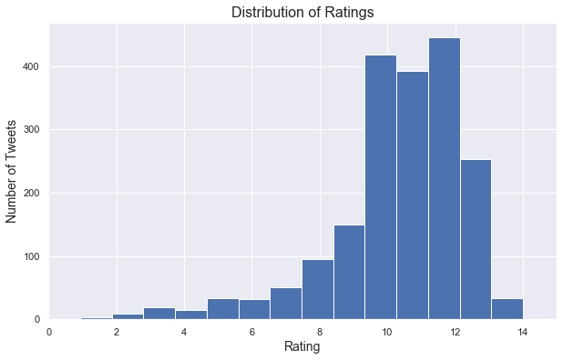

```python
Distribution of Ratings:
```

The distribution of ratings is highly skewed to the left. From the descriptive statistics above we see that 75% of all ratings are between 10 and 14 inclusive (the IQR is from 10 to 12).

```python
Top 5 fovourite tweet:
```

|  | tweet_id | timestamp | rating | retweet_count | favourite_count | dog_stage | breed | confidence | name | source |
| --- | --- | --- | --- | --- | --- | --- | --- | --- | --- | --- |
| 306 | 822872901745569793 | 2017-01-21 18:26:02+00:00 | 13 | 48265 | 132810 | puppo | Lakeland_Terrier | 19 | None | Twitter for iPhone |
| 763 | 744234799360020481 | 2016-06-18 18:26:18+00:00 | 13 | 79515 | 131075 | doggo | Labrador_Retriever | 82 | None | Twitter for iPhone |
| 58 | 879415818425184262 | 2017-06-26 19:07:24+00:00 | 13 | 45849 | 107956 | None | English_Springer | 38 | Duddles | Twitter for iPhone |
| 395 | 807106840509214720 | 2016-12-09 06:17:20+00:00 | 13 | 56625 | 107015 | None | Chihuahua | 50 | Stephan | Twitter for iPhone |
| 108 | 866450705531457537 | 2017-05-22 00:28:40+00:00 | 13 | 32883 | 106827 | pupper | French_Bulldog | 90 | Jamesy | Twitter for iPhone |

```python
Top 5 retweeted tweet
```

|  | tweet_id | timestamp | rating | retweet_count | favourite_count | dog_stage | breed | confidence | name | source |
| --- | --- | --- | --- | --- | --- | --- | --- | --- | --- | --- |
| 763 | 744234799360020481 | 2016-06-18 18:26:18+00:00 | 13 | 79515 | 131075 | doggo | Labrador_Retriever | 82 | None | Twitter for iPhone |
| 395 | 807106840509214720 | 2016-12-09 06:17:20+00:00 | 13 | 56625 | 107015 | None | Chihuahua | 50 | Stephan | Twitter for iPhone |
| 798 | 739238157791694849 | 2016-06-04 23:31:25+00:00 | 13 | 52360 | 75163 | doggo | Eskimo_Dog | 50 | None | Twitter for iPhone |
| 306 | 822872901745569793 | 2017-01-21 18:26:02+00:00 | 13 | 48265 | 132810 | puppo | Lakeland_Terrier | 19 | None | Twitter for iPhone |
| 58 | 879415818425184262 | 2017-06-26 19:07:24+00:00 | 13 | 45849 | 107956 | None | English_Springer | 38 | Duddles | Twitter for iPhone |

There are 4 tweets that are in the top 5 for both variables, nevertheless, it's interesting to note that the top favourited is the fourth most retweeted and, the top one retweeted holds the second postion in the most favourited tweets.

```python
Most common breeds?
```

```
Number of tweets with 'None' predicted breed:  302 (15%)
Number of distinct breeds:  113
```

```python
Top 10 dog breeds and number of tweet:
```

```
Breed and number of tweets
--------------------------
Golden_Retriever      154
Labrador_Retriever    103
Pembroke               94
Chihuahua              90
Pug                    62
Toy_Poodle             50
Chow                   47
Samoyed                42
Pomeranian             40
Malamute               33
Name: breed, dtype: int64

Top 10 dog breeds make up 37% of all tweets
```

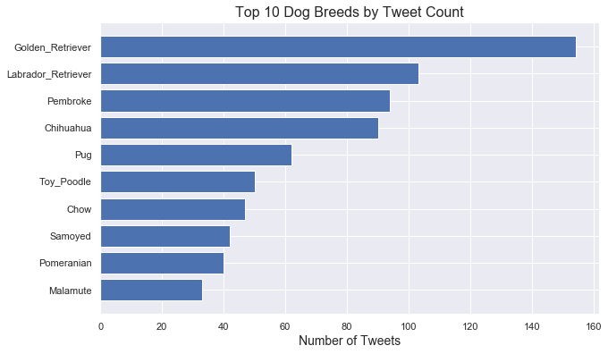

```python
Top 10 Dog Breeds by Tweet Count:
```

The bar chart above shows that the most common dog that is tweeted about, with almost 160 tweets, is the Golden Retriever, as identified (predicted) by the neural network. Labrador Retrievers, Pembrokes and Chihuahuas are fairly close together in 2nd, 3rd, and 4th place. Further down we will analyse at what are the most favourited dog breeds.

### Bivariate Anaysis

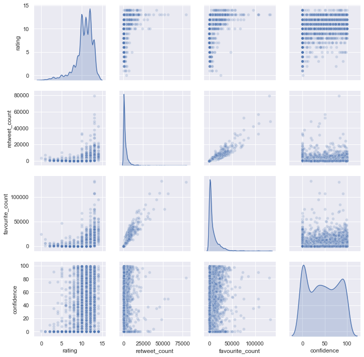

```python
Pairplot:
```

```python
Top 10 breed/favourite count:
```

```
breed
Golden_Retriever      1934793
Labrador_Retriever    1253364
Pembroke              1038797
Chihuahua              743689
Samoyed                583906
French_Bulldog         570921
Chow                   443610
Cocker_Spaniel         407412
Pug                    383817
Toy_Poodle             337270
Name: favourite_count, dtype: int64
```

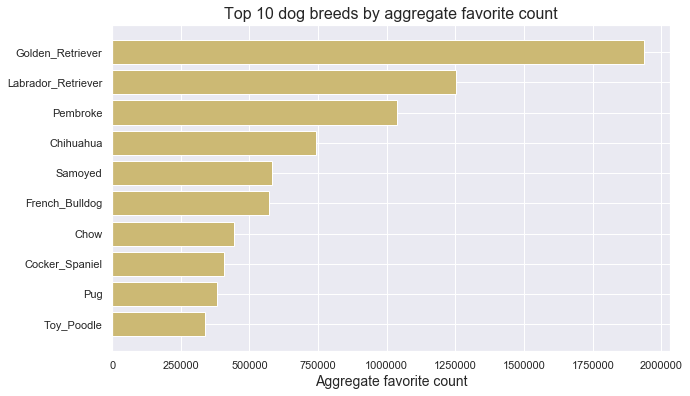

```python
Top 10 dog breeds by aggregate favorite count
```

The plot above shows the top 10 dog breeds ranked by aggregate favourite counts. It looks very similar to the barplot ealier of top 10 dog breeds ranked by tweet, and in fact the top 4 dog breeds are the same. This also makes sense, as these dogs have the highest number of tweets.

```python
Common breeds:
```

```
['Samoyed',
 'Chihuahua',
 'Pembroke',
 'Chow',
 'Golden_Retriever',
 'Pug',
 'Toy_Poodle',
 'Labrador_Retriever']
```

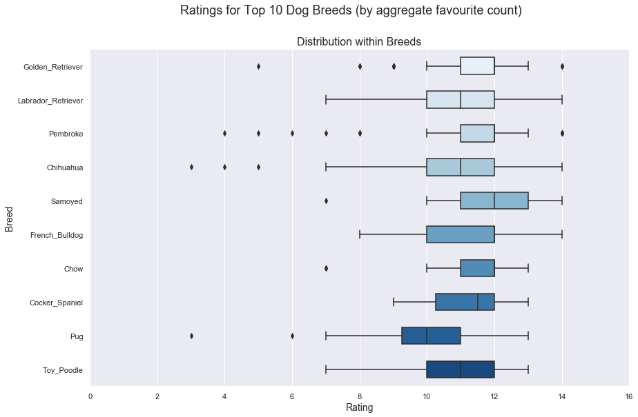

```python
Rating distribution within dog breeds with highest favourite count:
```

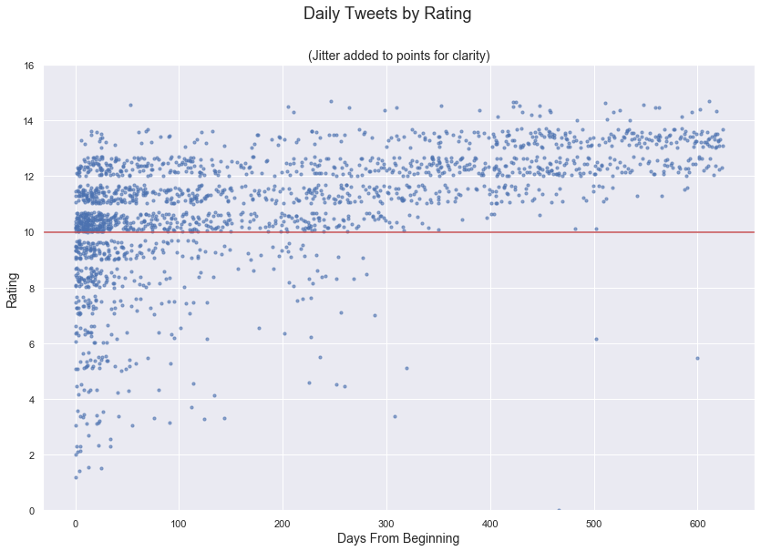

```python
Daily Tweets by Rating:
```

The plot here has the tweet ratings by day, showing how the ratings are generally over 10 in the latter half of the time period, after the account has been running for 300 days.

```python
Total number of tweets over time:
```

```
tweet_id    1952
dtype: int64
```

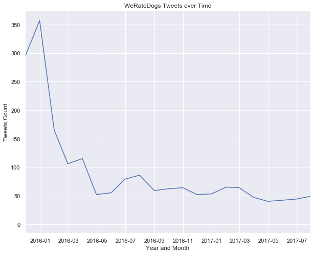

```python
WeRateDogs Tweets over Time:
```

Over time tweets decreased sharply, with spikes in activity during the early spring of 2016, mid-summer of 2016, and generally decreasing from there.

```python
Most popular dog names:
```

```
Name and number of tweets
--------------------------
Charlie    11
Lucy       10
Cooper     10
Oliver     10
Tucker      9
Penny       9
Sadie       8
Winston     8
Daisy       7
Lola        7
Name: name, dtype: int64

Top 10 dog name make up 5% of all tweets
```